# Nouveautés de PostgreSQL 10

Workshop 10

Dalibo & Contributors

# Nouveautés de PostgreSQL 10

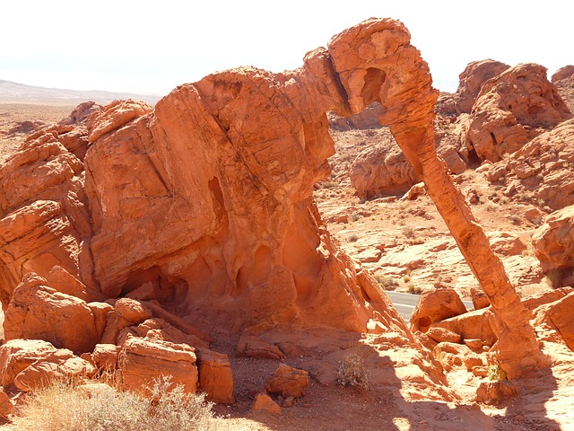

PostgreSQL

## Introduction

- Développement depuis août 2016
- Version beta 1 sortie le 18 mai
- Sortie de la version finale le 5 octobre 2017
- Plus de 1,4 million de lignes de code *C*
- Des centaines de contributeurs

### Au menu

- Changements importants
- Partitionnement
- Réplication logique
- Performances
- Sécurité
- Autres nouveautés
- Compatibilité
- Futur

## Changements importants

- Changement de la numérotation
- Changement de nommage
- Changement de configuration par défaut

### Numérotation des versions

Ancienne numérotation exprimée sur 3 nombres :

```
  9 . 6 . 3
  Majeure1 . Majeure2 . Mineure
```

Nouvelle numérotation exprimée sur 2 nombres uniquement :

```
  10 . 2
  Majeure . Mineure
```

### Nommage

- Au niveau des répertoires
  - `pg_xlog` -> `pg_wal`
  - `pg_clog` -> `pg_xact`
- Au niveau des fonctions
  - `xlog` -> `wal`
  - `location` -> `lsn`
- Au niveau des outils
  - `xlog` -> `wal`

### Configuration

- Changement des valeurs par défaut
- postgresql.conf
  - wal_level : replica
  - max_wal_senders : 10
  - max_replication_slots : 10
  - hot_standby : on
- pg_hba.conf
  - connexions de réplication autorisées sur localhost

## Partitionnement

- Petit rappel sur l’ancien partitionnement
- Nouveau partitionnement
- Nouvelle syntaxe
- Quelques limitations

### Ancien partitionnement

- Le partitionnement par héritage se base sur
  - la notion d’héritage (1 table mère et des tables filles)
  - des triggers pour orienter les insertions vers les tables filles
  - des contraintes d’exclusion pour optimiser les requêtes
- Disponible depuis longtemps

### Nouveau partitionnement

- Mise en place et administration simplifiées car intégrées au moteur
- Plus de trigger
  - insertions plus rapides
  - routage des données insérées dans la bonne partition
  - erreur si aucune partition destinataire
- Partitions
  - attacher/détacher une partition
  - contrainte implicite de partitionnement
  - expression possible pour la clé de partitionnement
  - sous-partitions possibles
- Changement du catalogue système
  - nouvelles colonnes dans `pg_class`
  - nouveau catalogue `pg_partitioned_table`

### Exemple de partitionnement par liste

- Créer une table partitionnée :

  `CREATE TABLE t1(c1 integer, c2 text) PARTITION BY LIST (c1);`
- Ajouter une partition :

  `CREATE TABLE t1_a PARTITION OF t1 FOR VALUES IN (1, 2, 3);`
- Détacher la partition :

  `ALTER TABLE t1 DETACH PARTITION t1_a;`
- Attacher la partition :

  `ALTER TABLE t1 ATTACH PARTITION t1_a FOR VALUES IN (1, 2, 3);`

### Exemple de partitionnement par intervalles

- Créer une table partitionnée :

  `CREATE TABLE t2(c1 integer, c2 text) PARTITION BY RANGE (c1);`
- Ajouter une partition :

  `CREATE TABLE t2_1 PARTITION OF t2 FOR VALUES FROM (1) TO (100);`
- Détacher une partition :

  `ALTER TABLE t2 DETACH PARTITION t2_1;`

### Clé de partitionnement multi-colonnes

- Clé sur plusieurs colonnes acceptée
  - uniquement pour le partitionnement par intervalles
- Créer une table partitionnée avec une clé multi-colonnes :

  `CREATE TABLE t1(c1 integer, c2 text, c3 date)` `PARTITION BY RANGE (c1, c3);`
- Ajouter une partition :

  `CREATE TABLE t1_a PARTITION of t1 FOR VALUES` `FROM (1,'2017-08-10') TO (100, '2017-08-11');`

### Performances en insertion

Table non partitionnée

```
INSERT INTO t1 SELECT i, 'toto'
  FROM generate_series(0, 9999999) i;
Time: 10097.098 ms (00:10.097)
```

Nouveau partitionnement

```
INSERT INTO t2 SELECT i, 'toto'
  FROM generate_series(0, 9999999) i;
Time: 11448.867 ms (00:11.449)
```

Ancien partitionnement

```
INSERT INTO t3 SELECT i, 'toto'
  FROM generate_series(0, 9999999) i;
Time: 125351.918 ms (02:05.352)
```

### Limitations

- La table mère ne peut pas avoir de données
- La table mère ne peut pas avoir d’index
  - ni PK, ni UK, ni FK pointant vers elle
- Pas d’UPDATE impliquant un changement de partition
- Pas de colonnes additionnelles dans les partitions
- Pas de mélange des deux types de partitionnement
- Une partition ne peut faire partie que d’une seule table partitionnée
- Valeurs nulles acceptées dans les partitions uniquement si la table partitionnée le permet
- Partitions distantes uniquement en lecture
- En cas d’attachement d’une partition
  - vérification du respect de la contrainte (verrou bloquant sur la partition)
  - sauf si ajout au préalable d’une contrainte `CHECK` identique

## Réplication logique

- Petit rappel sur la réplication physique
- Qu’est-ce que la réplication logique ?
- Fonctionnement
- Limitations
- Supervision
- Exemples

### Réplication physique

- Réplication de toute l’instance
  - au niveau bloc
  - par rejeu des journaux de transactions
- Quelques limitations :
  - intégralité de l’instance
  - même architecture (x86, ARM…)
  - même version majeure
  - pas de requête en écriture sur le secondaire

### Réplication logique - Principe

- Réutilisation de l’infrastructure existante
  - réplication en flux
  - slots de réplication
- Réplique les changements sur une seule base de données
  - d’un ensemble de tables défini
- Uniquement INSERT / UPDATE / DELETE
  - pas les DDL, ni les TRUNCATE

### Fonctionnement

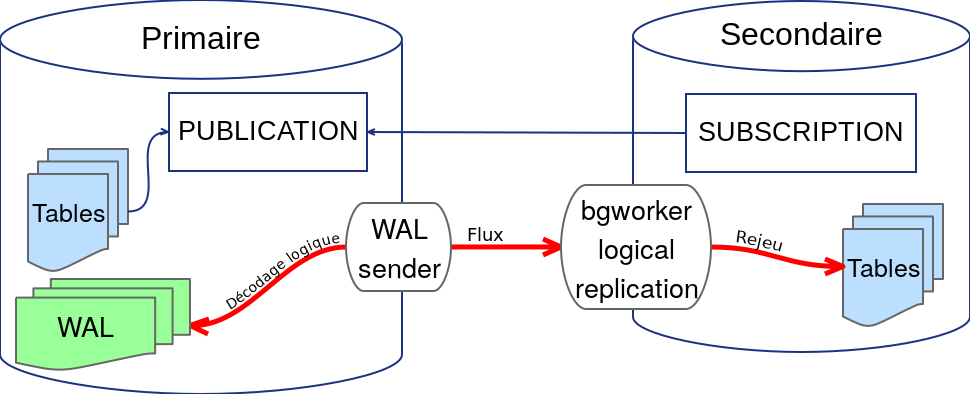

Schéma du fonctionnement de la réplication logique

### Limitations

- Non répliqué :
  - Schéma
  - Séquences
  - *Large objects*
- Pas de publication des tables parents du partitionnement
- Ne convient pas comme fail-over
- Contrainte d’unicité nécessaire pour `UPDATE` et `DELETE`

### Supervision

- Nouveaux catalogues
  - pg_publication
  - pg_subscription
  - pg_stat_subscription
- Anciens catalogues
  - pg_stat_replication
  - pg_replication_slot
  - pg_replication_origin_status

### Exemple - Création d’une publication

- Définir wal_level à logical
- Initialiser une base de données et sauvegarder son schéma
- Créer une publication pour toutes les tables

  `CREATE PUBLICATION ma_publication FOR ALL TABLES;`
- Créer une publication pour une table

  `CREATE PUBLICATION ma_publication FOR TABLE t1;`

### Exemple - Création d’une souscription

- Initialiser une base de données et importer son schéma
- Créer l’abonnement :

```sql
CREATE SUBSCRIPTION ma_souscription
CONNECTION 'host=127.0.0.1 port=5433 user=repliuser dbname=bench'
PUBLICATION ma_publication;
```

### Exemple - Visualisation de l’état de la réplication

- Sur l’éditeur
  - `pg_stat_replication` pour l’état de la réplication
  - `pg_replication_slots` pour la définition des slots de réplication
  - `pg_publication` pour la définition des publications
  - `pg_publication_tables` pour la liste des tables publiées par publication
- Sur l’abonné
  - `pg_subscription` pour la définition des abonnements
  - `pg_replication_origin_status` pour l’état de la réplication

## Performances

- Tris
- Agrégats
- Statistiques multi-colonnes
- Parallélisme

### Gain sur les tris

- Gains significatifs pour les tris sur disque
  - nœud `Sort Method: external merge`
- Test avec installation par défaut et disques SSD
  - 9.6 : 2,2 secondes
  - 10 : 1,6 secondes

### Gain sur les agrégats

- Exécution d’un agrégat par hachage (HashAggregate)
  - lors de l’utilisation d’un ensemble de regroupement (par exemple, un GROUP BY)
- Test avec installation par défaut et disques SSD :
  - 9.6 : 4,9 secondes
  - 10 : 2,6 secondes

### Statistiques multi-colonnes

- `CREATE STATISTICS`
  - création de statistiques sur plusieurs colonnes d’une même table
- Corrige les erreurs d’estimation en cas de colonnes fortement corrélées
- Deux statistiques calculables
  - nombre de valeurs distinctes
  - dépendances fonctionnelles

### Parallélisme - nouvelles opérations supportées

- Nœuds désormais gérés :
  - parcours d’index (`Index Scan` et `Index Only Scan`)
  - jointure-union (`Merge Join`)
- Nouveau nœud :
  - collecte de résultats en préservant l’ordre de tri (`Gather Merge`)
- Support également des :
  - requêtes préparées
  - sous-requêtes non-corrélées

### Parallélisme - paramétrage

- nouveaux paramètres
  - `min_parallel_table_scan_size` : taille minimale d’une table (8 Mo)
  - `min_parallel_index_scan_size` : taille minimale d’un index (512 ko)
- suppression de `min_parallel_relation_size`
  - jugé trop générique
- `max_parallel_workers` : nombre maximum de workers que le système peut supporter pour le besoin des requêtes parallèles

## Sécurité

- pg_hba.conf
- Row-Level Security
- Nouveaux rôles

### pg_hba.conf

- Nouvelle méthode d’authentification `SCRAM-SHA-256`
- Vue `pg_hba_file_rules`
- Par défaut, connexion locale de réplication possibles

### Row-Level Security

- Politique de sécurité pour l’accès aux lignes d’une table
- Nouvel attribut pour l’instruction `CREATE POLICY`
  - `PERMISSIVE` : politiques d’une table reliées par des `OR`
  - `RESTRICTIVE` : politiques d’une table reliées par des `AND`
- `PERMISSIVE` par défaut

### Nouveaux rôles

- Supervision normalement réservée aux super-utilisateurs
- Nouveaux rôles
  - pg_monitor
  - pg_read_all_settings
  - pg_read_all_stats
  - pg_stat_scan_tables

## Administration

- pg_stat_activity
- Architecture
- SQL/MED
- Quorum réplication synchrone
- Changements dans pg_basebackup
- pg_receivewal
- Index hash
- Renommage d’un enum

### pg_stat_activity

- Affichage des processus auxiliaires
  - nouvelle colonne `backend_type`
- Nouveaux types d’événements pour lesquels le processus est en attente
  - Activity
  - Extension
  - Client
  - IPC
  - Timeout
  - IO
- Renommage des types LWLockNamed et LWLockTranche en LWLock
- Impact sur les outils de supervision

### Architecture

- Amélioration des options de connexion de la librairie *libpq* :

```
psql --dbname="postgresql://127.0.0.1:5432,127.0.0.1:5433/ma_db?target_session_attrs=any"
```

- Ajout des slots de réplication temporaires
- Support de la librairie ICU pour la gestion des collations

### SQL/MED, Foreign Data Wrappers

- `file_fdw`
  - Récupération du résultat d’un programme comme entrée
- `postgres_fdw`
  - Support des agrégations et jointures (`FULL JOIN`) sur le serveur distant

### Quorum réplication synchrone

- Possibilités existantes de réplication synchrone avec une liste de plusieurs esclaves
  - Tous :

    `synchronous_standby_names = (s1, s2, s3, s4)`
  - Certains par ordre de priorité :

    `synchronous_standby_names = [FIRST] 3 (s1, s2, s3, s4)`
- Nouveauté
  - Certains sur la base d’un quorum :

    `synchronous_standby_names = [ANY] 3 (s1, s2, s3, s4)`

### Changements dans pg_basebackup

- Suppression de l’option `-x`
- Modification de la méthode de transfert des WAL par défaut
  - `none` : pas de récupération des WAL
  - `fetch` : récupération des WAL à la fin de la copie des données
  - `stream` : streaming (par défaut)
- Nommage des arguments longs
  - –xlog-method -> –wal-method
  - –xlogdir -> –waldir

### pg_receivewal

- Gestion de la compression dans `pg_receivewal`
  - niveau 0 : pas de compression
  - niveau 9 : meilleure compression possible

### Index Hash

- Journalisation
- Amélioration des performances
- Amélioration de l’efficacité sur le grossissement de ces index

### Renommage d’un enum

Renommage possible de la valeur d’un enum

```sql
ALTER TYPE nom RENAME VALUE valeur_enum_existante
TO nouvelle_valeur_enum;
```

## Utilisateurs

- Full Text Search sur du json
- Nouvelle fonction XMLTABLE
- psql, nouvelles méta-commandes
- Tables de transition
- Amélioration sur les séquences
- Nouveau type de colonne identity

### Full Text Search sur du json

- Type `json` et `jsonb`
- Impacte les fonctions `ts_headline()` et `to_tsvector()`

### XMLTABLE

- Transformation d’un document XML en table
- Nécessite libxml

### psql, nouvelles méta-commandes

- \gx, force l’affichage étendu de \g
- structure conditionnelle \if, \elif, \else, \endif

### Tables de transition

- Pour les triggers de type AFTER et de niveau STATEMENT
- Possibilité de stocker les lignes avant et/ou après modification
  - `REFERENCING OLD TABLE`
  - `REFERENCING NEW TABLE`
- Par exemple

```sql
CREATE TRIGGER tr1
AFTER DELETE ON t1
REFERENCING OLD TABLE AS oldtable
FOR EACH STATEMENT
EXECUTE PROCEDURE log_delete();
```

- Gain en performance

### Amélioration sur les séquences

- Création des catalogues système `pg_sequence` et `pg_sequences`
- Ajout de l’option `CREATE SEQUENCE AS type_donnee`

### Colonne identity

- Nouvelle contrainte `IDENTITY`
- Similaire au type `serial` mais conforme au standard SQL
- Géré par PostgreSQL ou modifiable :

```sql
CREATE TABLE t1 (id int PRIMARY KEY GENERATED ALWAYS AS IDENTITY) ;
CREATE TABLE t2 (id int PRIMARY KEY GENERATED BY DEFAULT AS IDENTITY) ;
```

## Compatibilité

- Changements dans les outils
- Les outils de la sphère Dalibo

### Changements dans les outils

- Changements de comportement :
  - `pg_ctl` attend désormais que l’instance soit démarrée avant de rendre la main (identique au comportement à l’arrêt)
- Fin de support ou suppression :
  - Type `floating point timestamp`
  - Contribution `tsearch2`
  - Support des versions < 8.0 dans `pg_dump`
  - Protocole client/serveur 1.0
  - Clause `UNENCRYPTED` pour les mots de passe

### Les outils de la sphère Dalibo

Les outils Dalibo sont à présent compatibles :

| Outil | Compatibilité avec PostgreSQL 10 |
| --- | --- |
| pgBadger | Oui |
| pgCluu | Oui, depuis 2.6 |
| ora2Pg | Oui (support du partitionnement déclaratif) |
| pg_stat_kcache | Oui, depuis 2.0.3 |
| ldap2pg | Oui |

## Futur

- Branche de développement de la version 11 créée le 15 août
  - … quelques améliorations déjà présentes
- Nouvelle fonctionnalité de préchauffage automatique du cache pour pg_prewarm
- Améliorations du partitionnement
  - partition par défaut
  - par hachage
  - possibilité de mise à jour de la clé de partitionnement
- Améliorations de la parallélisation
  - pour les InitPlan
  - pour les hachages
- Améliorations de la réplication logique
  - Fast Forward

## Questions

`SELECT * FROM questions;`

# Atelier

À présent, place à l’atelier…

- Installation
- Découverte de PostgreSQL 10
- Authentification avec SCRAM-SHA-256
- Vue pg_hba_file_rules
- Vue pg_sequence
- Modifications dans pg_basebackup
- Parallélisation
- Partitionnement
- Performances
- Collations ICU
- Réplication logique

## Installation

## Découverte de PostgreSQL 10

## Authentification avec SCRAM-SHA-256

## Vue pg_hba_file_rules

## Vue pg_sequence

## Modifications dans pg_basebackup

## Parallélisation

## Parallélisation : Parallel Bitmap Heap Scan

## Parallélisation : Parallel Index-Only Scan et Parallel Index Scan

## Parallélisation : transmission des requêtes aux workers

## Partitionnement : création

## Partitionnement : limitations

## Partitionnement : administration

## Performances

## Collations ICU

## Réplication logique : publication

## Réplication logique : souscription

## Réplication logique : modification des données